# Is it possible to make a million on Fiverr?

Insights from analysing Fiverr data to answer the question

The story of [How a dad made almost 1 million on Fiverr](https://www.cnbc.com/2018/04/24/how-this-dad-made-almost-1-million-on-fiverr.html?__source=msn%7Cmoney%7Cinline%7Cstory%7C&par=msn&doc=105300315) inspired me to analyse real data from Fiverr to gain insights on how realistic a story like this is. First, I was looking for more stories from people to get an idea of what they earn and what they are doing.

| Seller | Type of service | Income |
| --- | --- | --- |
| [Joel Young](https://www.cnbc.com/2018/04/24/how-this-dad-made-almost-1-million-on-fiverr.html?__source=msn%7Cmoney%7Cinline%7Cstory%7C&par=msn&doc=105300315) | Voice Over | $1,000,0000 |
| [Charmaine Pocek](https://www.forbes.com/sites/laurashin/2016/05/31/how-these-3-people-make-6-figures-a-year-on-fiverr/) | Resume writing | $480,000 |
| [Levi Newman](https://www.forbes.com/sites/laurashin/2016/05/31/how-these-3-people-make-6-figures-a-year-on-fiverr/) | Copywriting | $180,000 |
| [Redd Horrocks](https://www.forbes.com/sites/laurashin/2016/05/31/how-these-3-people-make-6-figures-a-year-on-fiverr/) | Voice Over | $180,000 |
| [Alex Fasulo](https://www.msn.com/en-us/money/bills-to-pay/how-this-25-year-old-freelancer-made-dollar150000-in-6-months-off-fiverr/ar-AAzkNOA) | Press Release Writing | $150,000 |
| [David Feldman](https://www.cnbc.com/2018/12/18/how-this-38-year-old-is-making-6-figures-freelancing-on-fiverr.html) | Copywriting | $100,000 |

These numbers are impressing! It looks like an attractive business model.

## Are they exaggerators?

We are in a world of self-marketing, everybody wants to get on page one with his story to push his business. Why not cheat a bit with the numbers? I will fetch real data from Fiverr to get an idea of how realistic the numbers are.

First, I identified the usernames of the sellers, which was not difficult. Then I extracted the data for the gigs these sellers are offering. You can retrieve the price, and you can see the number of reviews, which lets you calculate a metric “reviewed revenue”. Afterwards, you can add up the revenue for all gigs somebody is offering to get an impression of the seller’s total revenue.

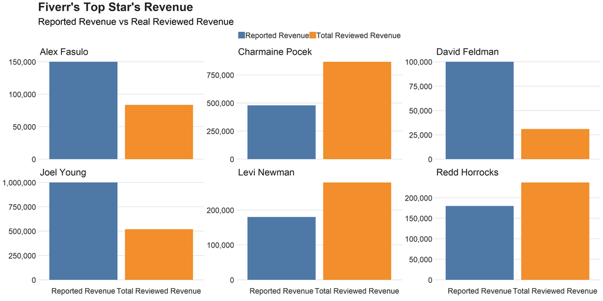

The reviewed revenue of David Feldman, Joel Young and Alex Fasulo is lower than the income reported in the stories. The reviewed revenue is by a factor between 0.3 and 0.5 lower. On the other hand, for Redd Horrocks, Levi Newman and Charmaine Pocek the reviewed revenue is by a factor between 1.3 and 1.8 higher than the reported income.

So our first impression could be: We caught all of them on lying and David, Joel and Alex are terrible exaggerators.

This view is a bit too simplified. I was curious what’s the rated order ratio is on Fiverr. I found a post on the Fiverr forum on it: [What is your Rated Orders percentage?](https://forum.fiverr.com/t/what-is-your-rated-orders-percentage/143919/6) and I asked the sellers on Reddit for their [rated order ratio](https://www.reddit.com/r/Fiverr/comments/b8h1pn/help_what_is_your_rated_order_ratio/). People report ratios at around 80%, which seems very high to me. I decided to take a value of about 50%. With this ratio the revenues of Alex, Joel and David seem realistic (no liers). It means on the other hand that Redd, Levi and Charmaine are making much money than they reported.

I calculated the realistic revenue numbers for the sellers with a rated order ratio of 0.5

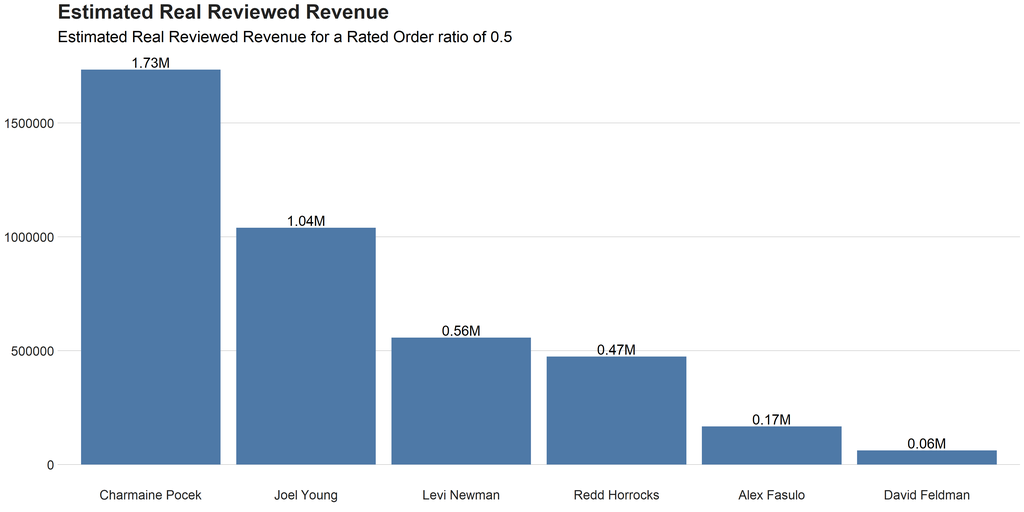

With this estimation, we can see that Joel Young and Charmaine Pocek are most probably made over million on Fiverr. But also Levi Newman and Redd Horrocks are making quite a bit of money.

## What gigs?

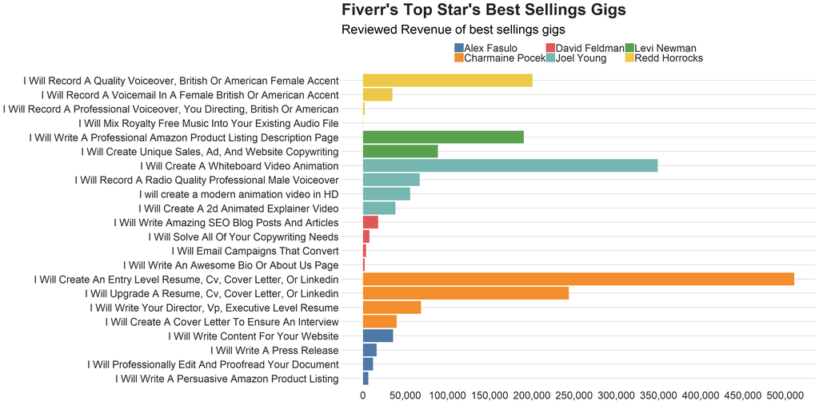

This unbelievable: One single gig is making over 500,000.

But is this realistic to everybody of us?

## Can everybody be a superstar?

Can everybody make 500k with one single Gig?

I analysed 2634 Gigs in 57 niches to answer this question:

Are there other gigs that made over a 100,000 reviewed revenue?

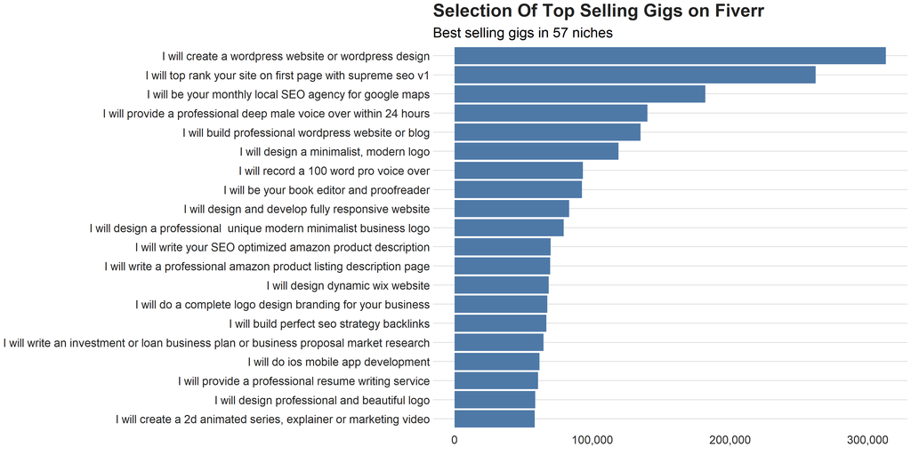

This shows you that more people are making a ton of money on Fiverr.

## How realistic is it to make your first million on Fiverr?

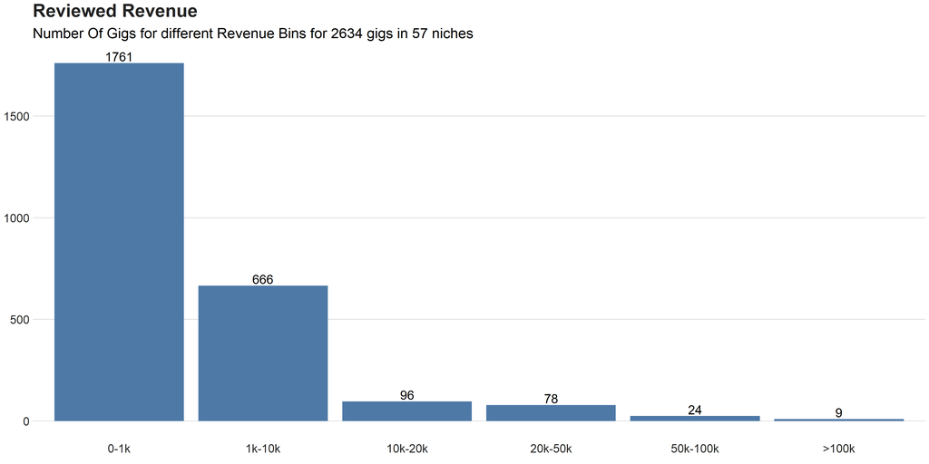

You can see that the majority of Gigs made less than 1,000. Reaching between 1,000-10,000 is possible, but everything over that is quite hard to achieve.

## Conclusion

We answered the question if it is possible to make 1,0000,000 on Fiverr. We could prove that it is possible and that there are even more superstars on Fiverr who are making a lot of money. But we also learned earning these amounts is a tough job.

It’s maybe a good idea to find more superstars and learn from them.